# Homework 9

Key

### Part 1

This part of the homework uses [Jenny Bryan](https://jennybryan.org/)’s [Lord of the Rings tidy data materials](https://github.com/jennybc/lotr-tidy).

#### 1. Create a new RStudio Project and name it `hw_9`

#### 2. Within that project, create a new R Markdown document and modify the YAML to:

- Include your name
- Render to html
- Change the syntax highlighting to any scheme but the default
- Include code folding
- Include a floating table of contents
  - Use level 1 headers for items (4) through (8) below
  - Use level 2 headers for your table and plot in (7) below

#### 3. Your first code chunk should:

- Be named `setup`
- Set global chunk options for the document to display and evaluate all code, and not display any warnings or messages
- Load all the necessary packages (please don’t load packages you do **not** use)
- Include options for this code chunk so it will not display the code or the results from the code.

#### 4. Your second code chunk should:

- Be named `data`
- Import the following three data sets, each as separate objects
  - *The_Fellowship_Of_The_Ring.csv*
  - *The_Two_Towers.csv*
  - *The_Return_Of_The_King.csv*
    - (These data sets show the **words spoken** by characters of different races and genders in the *Lord of the Ring*s movie trilogy.)
- Combine these three data sets into one data set as a new object named `lotr_tidy`

```r
fotr <- import(here("data", "The_Fellowship_Of_The_Ring.csv"))

tt <- import(here("data", "The_Two_Towers.csv"))

rotk <- import(here("data", "The_Return_Of_The_King.csv"))

lotr_untidy <- bind_rows(fotr, tt, rotk) %>%
  as_tibble()
```

#### 5. Describe why the combined data set is not tidy.

#### 6. Your third code chunk should:

- Have a meaningful name (do not use spaces or capital letters)
- Tidy the combined data set
- Save the tidy data to the data folder in your project as `lotr_tidy`

```r
lotr_tidy <- lotr_untidy %>%
  pivot_longer(
    cols = c(Female, Male),
    names_to = "Gender",
    values_to = "Words"
  )

export(lotr_tidy, here("data", "lotr_tidy.csv"))
```

#### 7. Your fourth code chunk should include code that:

- Reads in the *Female.csv* and *Male.csv* files and saves a single tidy data frame to file
- This should reproduce exactly the `lotr_tidy` data from above
- Compute the total number of words spoken by each race across the entire trilogy.
- Show these results in a table and a figure.

```r
d <- import(here("data", "Female.csv")) %>%
  bind_rows(import(here("data", "Male.csv"))) %>%
  rename(Human = Man) %>%
  pivot_longer(
    cols = c(Elf, Hobbit, Human),
#OR cols = -c(film, Gender)
    names_to = "Race",
    values_to = "Words"
  ) %>%
  select(names(lotr_tidy))
#OR select(Film, Race, Gender, Words)

d_summary <- d %>%
  group_by(Race) %>%
  summarize(total_words = sum(Words))
```

**Total number of words spoken by each race across the entire LOTR trilogy**

**Table**

```r
d_summary %>%
  kable(digits = 2,
         col.names = c("Race", "Total Words")) %>%
  kable_styling(latex_options = "striped", full_width = FALSE)
```

| Race | Total Words |
| --- | --- |
| Elf | 3737 |
| Hobbit | 8796 |
| Human | 8712 |

**Figure**

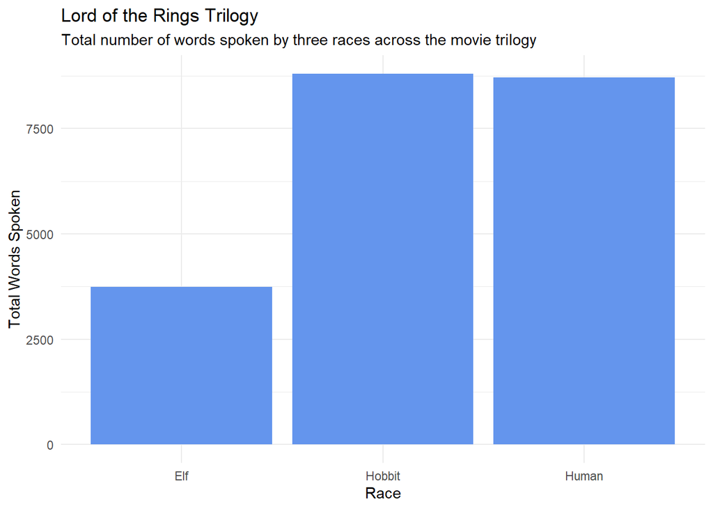

```r
d_summary %>%
  ggplot(aes(Race, total_words)) +
  geom_col(fill = "cornflowerblue") +
  theme_minimal() +
  labs(y = "Total Words Spoken",
       title = "Lord of the Rings Trilogy",
       subtitle = "Total number of words spoken by three races across the movie trilogy")
```

#### 8. Let’s make messy data. Your fifth code chunk should include code that uses `lotr_tidy` and `pivot_wider()` to:

- Get one variable per `Race.` Save this as an object
- Get one variable per `Gender.` Save this as an object

```r
messy_by_race <- lotr_tidy %>%
  pivot_wider(
    names_from = Race,
    values_from = Words,
  )

messy_by_gender <- lotr_tidy %>%
  pivot_wider(
    names_from = Gender,
    values_from = Words,
  )
```

### Part 2

#### 1. Tidy the *Project Reads* data

- Load the **Project_Reads_Scores.csv** file
- Remove columns 5-9, 24, and 25
- Filter to remove the rows in *student_id* that represent aggregate summaries
- Tidy the remaining dataset such that a case represents a score and percentage within a unit (i.e., *score* and *percentage* will be separate columns). Take a VERY close look at the data. You will be able to use the `names_sep` argument if you **first** `rename()` two columns. Identify those two columns first. Also, you will need to first `pivot_longer` and then `pivot_wider` in order to tidy properly. In these data, “tidy” is a row for each of the seven *units* for every *student_id*.

```r
library(janitor)
library(ggthemes)

theme_set(theme_minimal())

reads <- read_csv(here("data", "Project_Reads_Scores.csv")) %>%
  clean_names()


reads_tidy <- reads %>%
  select(4, 1:3, 10:23) %>%
  rename("unit_56_score" = "unit_5_6_score",
         "unit_56_percent" = "unit_5_6_percent") %>%
  filter(student_id != "All Students (Average)") %>%
  pivot_longer(
    cols = contains("unit"),
    names_prefix = "unit_",
    names_sep = "_",
    names_to = c("unit", "score_type"),
    values_to = "score",
    values_transform = list(score = as.character)
  ) %>%
  mutate(score = parse_number(score)) %>%
  pivot_wider(
    names_from = score_type,
    values_from = score
  )
```

#### 2. Produce a summary table of the mean percentage correct for each unit within test sites. Report the summary in a table.

```r
reads_summary <- reads_tidy %>%
    group_by(test_site, unit) %>%
    summarize(percent = mean(percent))
reads_summary
```

```
## # A tibble: 21 x 3
## # Groups:   test_site [3]
##    test_site unit  percent
##    <chr>     <chr>   <dbl>
##  1 JONES     1        8.27
##  2 JONES     2       13.3
##  3 JONES     3       17.1
##  4 JONES     4       22.7
##  5 JONES     56      29.5
##  6 JONES     7       46.5
##  7 JONES     8       52.4
##  8 VIRDEN    1       16.8
##  9 VIRDEN    2       18.4
## 10 VIRDEN    3       24.8
## # ... with 11 more rows
```